# Visit Scotland Final Project

## Plot set # 4 - activities

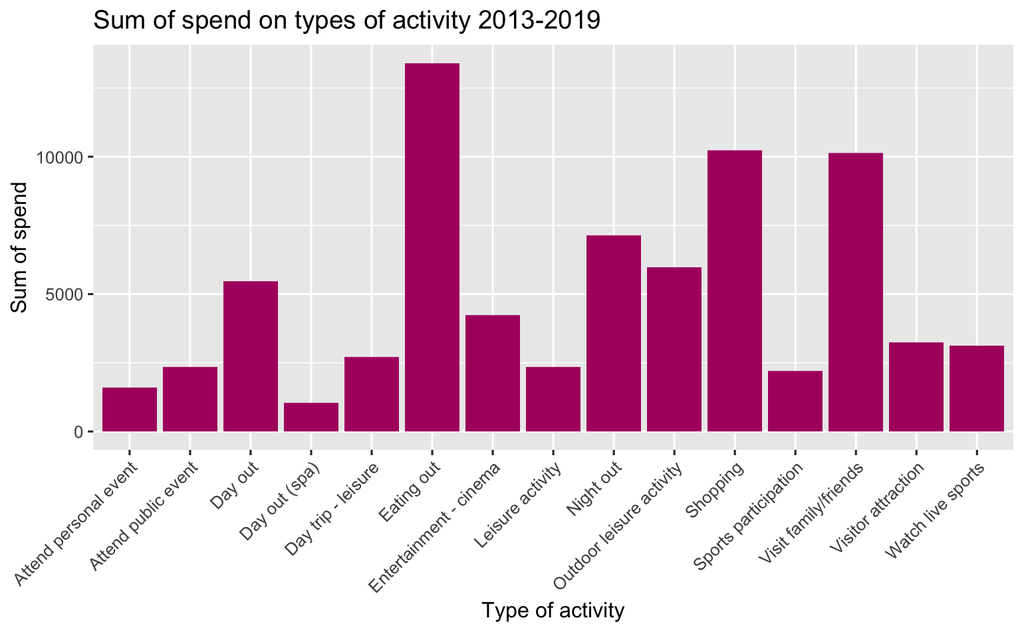

2013-2019, sum of value in million pounds. Highest is eating out (with shopping and visiting family/friends following)

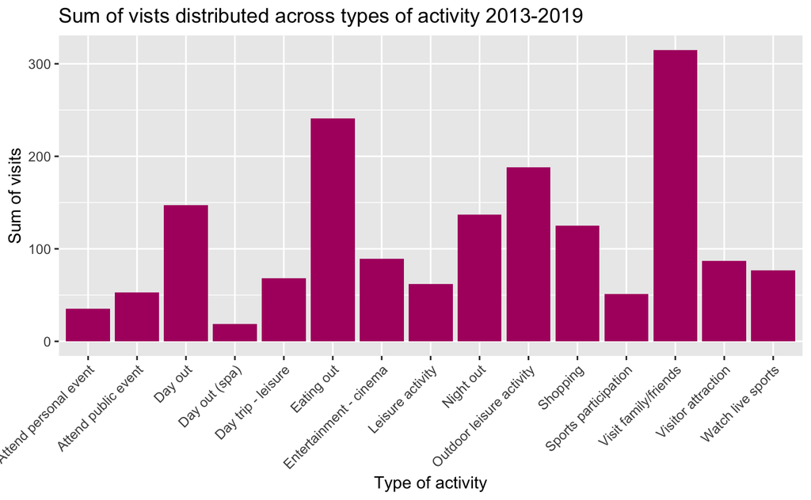

2013-2019, sum of million visits. Highest is visits with family/friends. Eating out coming in second, and outdoor leisure in third.

## Plot set # 5 - demographics

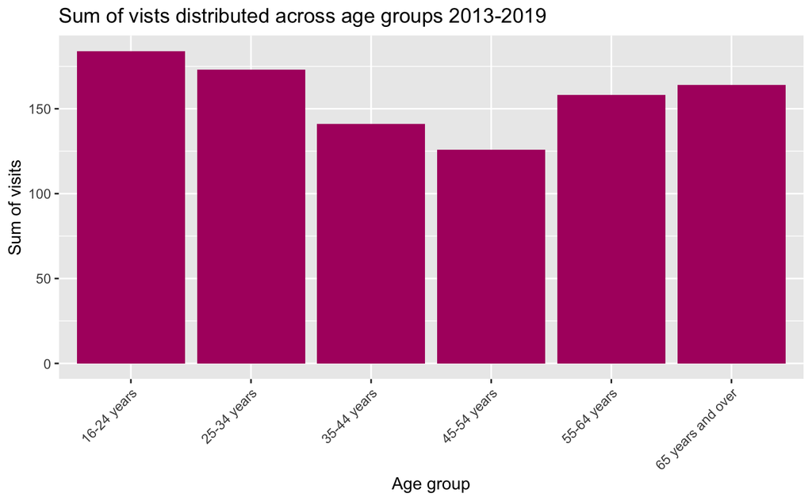

Yes, and no. The data from this dataset isn’t great for analysis, because a lot of inferences have to be drawn. A key insight to be drawn from this is to complete further research / get better data.

NOTE TO MYSELF - if I have time, dig further into this, across the different years / visits / spends.

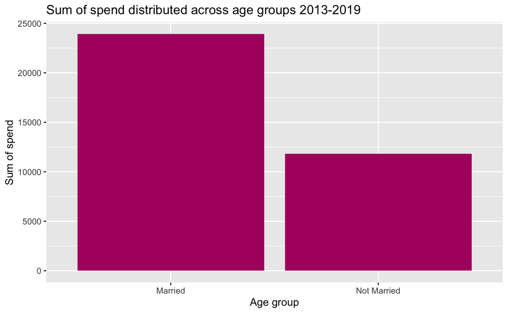

This is where the data is limited, because the survey / options for respondents was limited, so marital_status can’t really be fairly compared. However, going by the data strictly (because this does still reflect something, and even when grouping age so that they could be compared, the “married” response comes out higher).

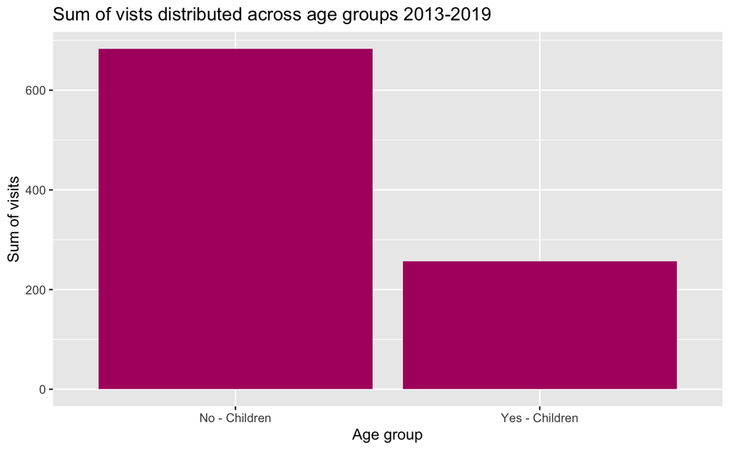

This is the same issue, but also response / relevance, as the above.

[output not shown]

## Plot set # 6 - regional demographics

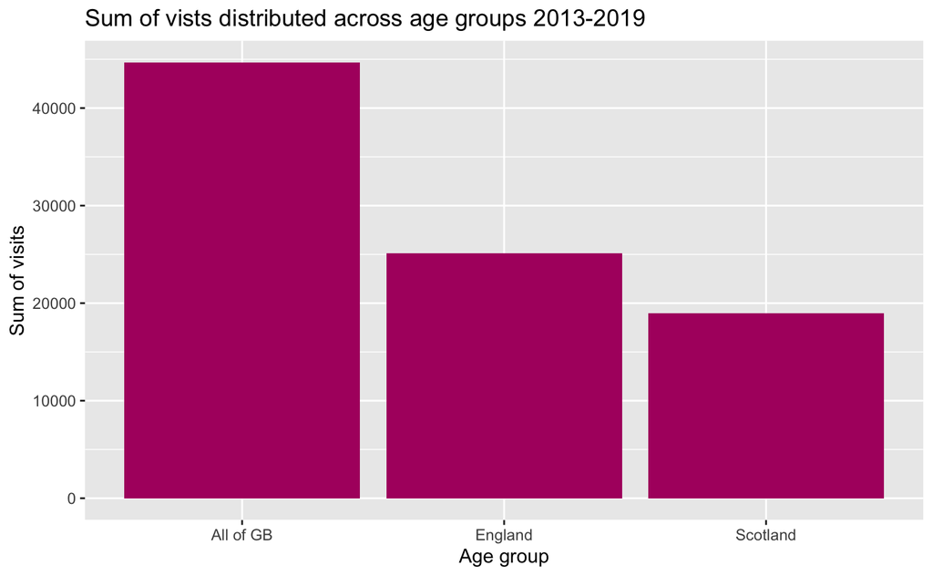

```r
# When looking at regional tourism, what insights can we gain? Where are our visitors from? How do they differ in the money they spend, nights they spend in Scotland, or number of visits they do?

regional_domestic %>%
  filter(breakdown_of_domestic_tourism == "Nights") %>%
  ggplot(aes(x = region_of_residence, y = value, fill = breakdown_of_domestic_tourism)) +
  geom_col(position = "dodge") +
  theme(legend.position = "none") +
  labs(x = "Age group",
       y = "Sum of visits",
       title = "Sum of vists distributed across age groups 2013-2019") +
  scale_fill_manual(values = "#af006e")
```

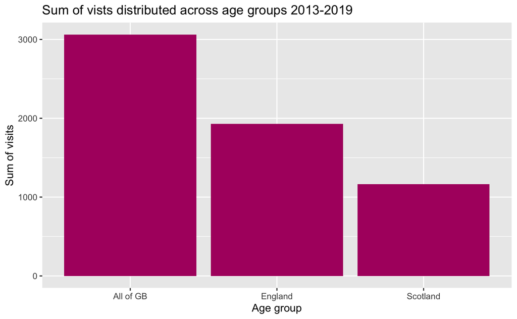

```r
regional_domestic %>%
  filter(breakdown_of_domestic_tourism == "Expenditure") %>%
  ggplot(aes(x = region_of_residence, y = value, fill = breakdown_of_domestic_tourism)) +
  geom_col(position = "dodge") +
  theme(legend.position = "none") +
  labs(x = "Age group",
       y = "Sum of visits",
       title = "Sum of vists distributed across age groups 2013-2019") +
  scale_fill_manual(values = "#af006e")
```

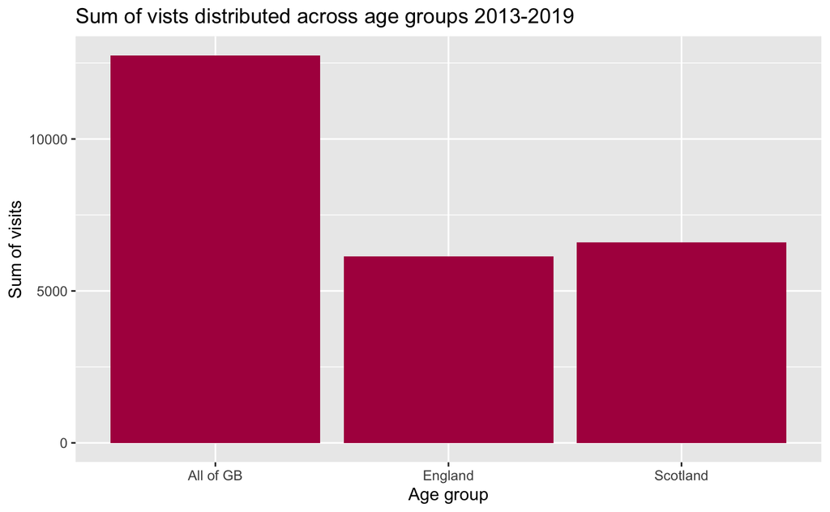

```r
regional_domestic %>%
  filter(breakdown_of_domestic_tourism == "Visits") %>%
  ggplot(aes(x = region_of_residence, y = value, fill = breakdown_of_domestic_tourism)) +
  geom_col(position = "dodge") +
  theme(legend.position = "none") +
  labs(x = "Age group",
       y = "Sum of visits",
       title = "Sum of vists distributed across age groups 2013-2019") +
  scale_fill_manual(values = "#af004e")
```

## Plot set # 7 - change over time

[figure not shown]

```r
# Number of visits they do?
regional_domestic %>%
  filter(breakdown_of_domestic_tourism == "Visits") %>%
  ggplot(aes(x = breakdown_of_domestic_tourism, y = value, fill = region_of_residence)) +
  geom_col(position = "dodge")
```

The *general* picture over time, is that for visits, it increases until 2017, and then declines (some more than others). For expenditure, it increases until 2017, declines in 2018, and increases again in 2019.